# univariate models

##### **Exercise**

Create a single plot that displays the model of y given x3 before and after the outliers were removed. How much to they visually differ from one another. Modify the arguments to `abline()` including `lty` and `lwd`.

[Show answer]

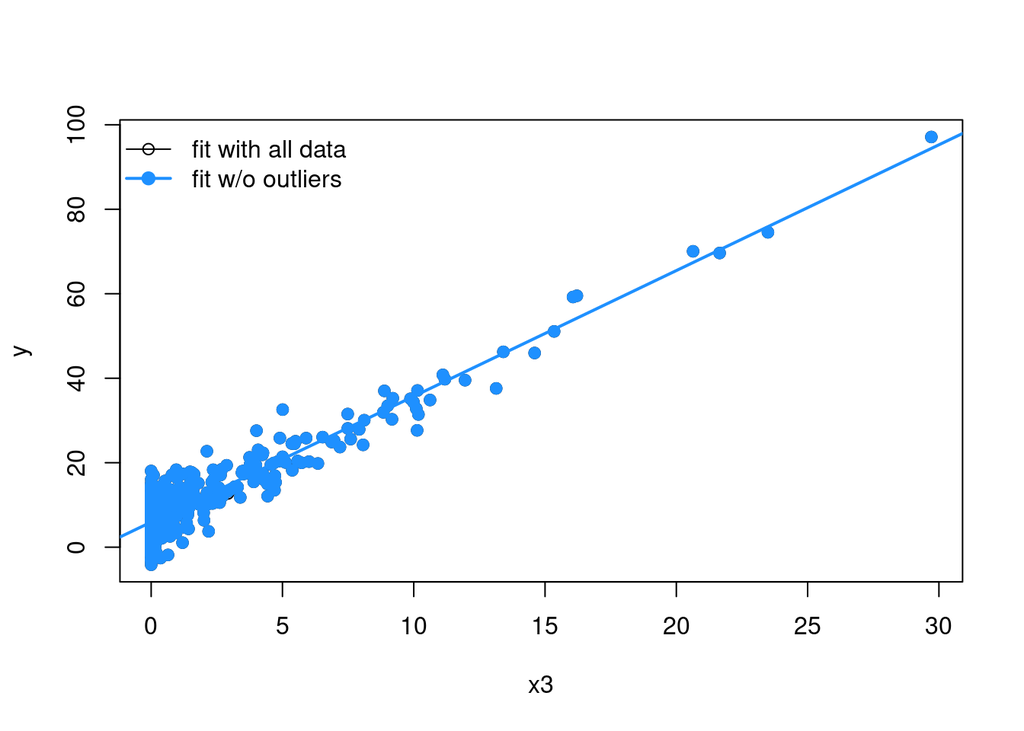

```r
plot(y ~ x3, data=sim_data)
points(y ~ x3, data=sim_data_sub, col='dodgerblue', pch=19)
abline(mod3)
abline(mod3_sub, col='dodgerblue', lwd=2)
legend('topleft', c('fit with all data', 'fit w/o outliers'),
       col=c('black', 'dodgerblue'), pch=c(1, 19), lty=1,
       lwd=c(1,2), bty='n')
```

### Multiple regression

So far we have only examined models with a single variable but by design we know that y is influenced by three variables. Let’s include all the relevant explanatory variables in one model now.

```r
mod_main <- lm(y ~ x1 + x2 + x3, data=sim_data)
summary(mod_main)
```

```
##
## Call:
## lm(formula = y ~ x1 + x2 + x3, data = sim_data)
##
## Residuals:
##      Min       1Q   Median       3Q      Max
## -10.5652  -1.9274  -0.0122   1.9385  11.1587
##
## Coefficients:
##             Estimate Std. Error t value Pr(>|t|)
## (Intercept) -0.12607    0.38847  -0.325    0.746
## x1           2.03852    0.35835   5.689 1.73e-08 ***
## x2           1.01568    0.06629  15.323  < 2e-16 ***
## x3           2.99037    0.03961  75.500  < 2e-16 ***
## ---
## Signif. codes:  0 '***' 0.001 '**' 0.01 '*' 0.05 '.' 0.1 ' ' 1
##
## Residual standard error: 3.118 on 896 degrees of freedom
## Multiple R-squared:  0.8687, Adjusted R-squared:  0.8682
## F-statistic:  1976 on 3 and 896 DF,  p-value: < 2.2e-16
```

```r
coefficients(mod_main)
```

```
## (Intercept)          x1          x2          x3
##   -0.126067    2.038523    1.015678    2.990369
```

Notice that in the output above the coefficient estimates are close to what we set them at when we created the variable `y`.

Home Page - http://dmcglinn.github.io/quant_methods/ GitHub Repo - https://github.com/dmcglinn/quant_methods